# TODO: Dog Breed Classification

This notebook lists all the steps that you need to complete the complete this project. You will need to complete all the TODOs in this notebook as well as in the README and the two python scripts included with the starter code.

**TODO**: Give a helpful introduction to what this notebook is for. Remember that comments, explanations and good documentation make your project informative and professional.

This notebook uses AWS Sagemaker to finetune a pretrained model that can perform image classification. It uses Sagemaker profiling, debugger, hyperparameter tuning and other good ML engineering practices. The dataset used is the dog breed classication dataset to classify between different breeds of dogs in images.

**Note:** This notebook has a bunch of code and markdown cells with TODOs that you have to complete. These are meant to be helpful guidelines for you to finish your project while meeting the requirements in the project rubrics. Feel free to change the order of these the TODO's and use more than one TODO code cell to do all your tasks.

```python
# TODO: Install any packages that you might need
# For instance, you will need the smdebug package
!pip install smdebug #For Amazon Sagemaker Debugger
```

```python
# TODO: Import any packages that you might need
# For instance you will need Boto3 and Sagemaker
import sagemaker
import boto3
```

## Dataset

TODO: Explain what dataset you are using for this project. Maybe even give a small overview of the classes, class distributions etc that can help anyone not familiar with the dataset get a better understand of it.

- The dog breed dataset consists of 133 breeds. Using our model, we can classify our pictures into their respective breeds.

```python
#TODO: Fetch and upload the data to AWS S3

# Command to download and unzip data
!wget https://s3-us-west-1.amazonaws.com/udacity-aind/dog-project/dogImages.zip
!unzip dogImages.zip
```

[output not shown]

[output cut: 8711 more lines]

[output not shown]

```python
# Uploading to S3
sagemaker_session = sagemaker.Session() # Obtain current sagemaker session

bucket = sagemaker_session.default_bucket() # Obtain current bucket
prefix = "dog-image-data" # Bucket prefix
role = sagemaker.get_execution_role() # Obtain current execution role
inputs = sagemaker_session.upload_data(path="dogImages", bucket=bucket, key_prefix=prefix)
```

## Hyperparameter Tuning

**TODO:** This is the part where you will finetune a pretrained model with hyperparameter tuning. Remember that you have to tune a minimum of two hyperparameters. However you are encouraged to tune more. You are also encouraged to explain why you chose to tune those particular hyperparameters and the ranges.

**Note:** You will need to use the `hpo.py` script to perform hyperparameter tuning.

```python
import sagemaker
# Import different types of parameters (Integer, Categorical, Continuous) and the HyperParameterTuner
from sagemaker.tuner import (
    IntegerParameter,
    CategoricalParameter,
    ContinuousParameter,
    HyperparameterTuner,
)
```

```python
#TODO: Declare your HP ranges, metrics etc.
'''
lr - Learning Rate - If the LR is too small, overfitting can occur.
Large lr help to regularize the training but if it is too large, the training will diverge.


batch-size - The batch size is limited by your hardware’s memory, while the learning rate is not.
small batch sizes add regularization while large batch sizes add less

epochs - this value is key to finding the model that represents the sample with less error
One epoch leads to underfitting.
As the number of epochs increases, and the model goes from underfitting to optimal to overfitting.
'''

hyperparameter_ranges = {
    "lr": ContinuousParameter(0.001, 0.1),
    "batch-size": CategoricalParameter([32, 64, 128, 256, 512]),
    "epochs": IntegerParameter(2, 4)
}

'''
objective_metric_name - Name of the metric for evaluating training jobs.

objective_type - The type of the objective metric for evaluating training jobs.
This value can be either ‘Minimize’ or ‘Maximize’

metric_definitions - A list of dictionaries that defines the metric(s) used to evaluate the training jobs
Each dictionary contains two keys: ‘Name’ for the name of the metric, and ‘Regex’ for the regular
expression used to extract the metric from the logs.
'''

objective_metric_name = "accuracy"
objective_type = "Maximize"
metric_definitions = [{"Name": "accuracy", "Regex": "\((\d+)%\)"}]
```

```python
#TODO: Create estimators for your HPs
'''
estimator -
Handles end-to-end training and deployment of custom PyTorch code.

This Estimator executes functions defined in the supplied entry_point Python script within
a SageMaker Training Job in a managed PyTorch execution environment.
'''
from sagemaker.pytorch import PyTorch

estimator = PyTorch(
    entry_point="hpo.py",
    role=role,
    py_version='py36',
    framework_version="1.8",
    instance_count=1,
    instance_type="ml.m5.xlarge"
)
'''
tuner - It takes an estimator to obtain configuration information for training jobs that are created
as the result of a hyperparameter tuning job.
'''
tuner = HyperparameterTuner(
    estimator,
    objective_metric_name,
    hyperparameter_ranges,
    metric_definitions,
    max_jobs=4,
    max_parallel_jobs=4,
    objective_type=objective_type,
)
```

```python
#Defining data channels
train_images_path = f"s3://{bucket}/dog-image-data/train"
print(train_images_path)
validation_images_path = f"s3://{bucket}/dog-image-data/valid"
print(validation_images_path)
```

```
s3://sagemaker-us-east-1-924884738416/dog-image-data/train
s3://sagemaker-us-east-1-924884738416/dog-image-data/valid
```

```python
# TODO: Fit your HP Tuner
tuner.fit({"train": train_images_path, "test": validation_images_path})
 # TODO: Remember to include your data channels
```

[output not shown]

```python
# TODO: Get the best estimators and the best HPs

best_estimator = tuner.best_estimator() #Obtaining best estimator

#Get the hyperparameters of the best trained model
best_estimator.hyperparameters()
```

```
2022-01-14 18:33:07 Starting - Preparing the instances for training
2022-01-14 18:33:07 Downloading - Downloading input data
2022-01-14 18:33:07 Training - Training image download completed. Training in progress.
2022-01-14 18:33:07 Uploading - Uploading generated training model
2022-01-14 18:33:07 Completed - Training job completed
```

```
{'_tuning_objective_metric': '"accuracy"',
 'batch-size': '"512"',
 'epochs': '4',
 'lr': '0.0035640524743305035',
 'sagemaker_container_log_level': '20',
 'sagemaker_estimator_class_name': '"PyTorch"',
 'sagemaker_estimator_module': '"sagemaker.pytorch.estimator"',
 'sagemaker_job_name': '"pytorch-training-2022-01-14-17-57-24-795"',
 'sagemaker_program': '"hpo.py"',
 'sagemaker_region': '"us-east-1"',
 'sagemaker_submit_directory': '"s3://sagemaker-us-east-1-924884738416/pytorch-training-2022-01-14-17-57-24-795/source/sourcedir.tar.gz"'}
```

## Model Profiling and Debugging

TODO: Using the best hyperparameters, create and finetune a new model

**Note:** You will need to use the `train_model.py` script to perform model profiling and debugging.

```python
# TODO: Set up debugging and profiling rules and hooks
'''
sagemaker.debugger -
The SageMaker Debugger module provides high-level methods to set up Debugger configurations to monitor,
profile, and debug your training job.

rule_configs - A helper module to configure the SageMaker Debugger built-in rules with the
Rule classmethods and and the ProfilerRule classmethods.

Rule - The SageMaker Debugger Rule class configures debugging rules to debug your training job.
The debugging rules analyze tensor outputs from your training job and monitor conditions that
are critical for the success of the training job.

'''
from sagemaker.debugger import Rule, ProfilerRule, rule_configs

rules = [
    ProfilerRule.sagemaker(rule_configs.LowGPUUtilization()),
    ProfilerRule.sagemaker(rule_configs.ProfilerReport()),
    Rule.sagemaker(rule_configs.vanishing_gradient()),
    Rule.sagemaker(rule_configs.overfit()),
]

from sagemaker.debugger import DebuggerHookConfig, ProfilerConfig, FrameworkProfile
# Configuration for collecting system and framework metrics of SageMaker training jobs.

profiler_config = ProfilerConfig(
    system_monitor_interval_millis=500, framework_profile_params=FrameworkProfile(num_steps=10)
)

# DebuggerHookConfig provides options to customize how debugging information is emitted and saved.

debugger_config = DebuggerHookConfig(
    hook_parameters={"train.save_interval": "10", "eval.save_interval": "1"}
)

#Hyperparameters of the best estimator

hyperparameters = {
    "batch-size": "512",
    "epochs": 4,
    "lr": "0.0035640524743305035",
}
```

```python
# TODO: Create and fit an estimator with the fine tuned model
from sagemaker.pytorch import PyTorch


estimator = PyTorch(
    role=sagemaker.get_execution_role(),
    instance_count=1,
    instance_type="ml.m5.2xlarge",
    source_dir=".",
    entry_point="train_model.py",
    framework_version="1.8",
    py_version="py36",
    hyperparameters=hyperparameters,
    profiler_config=profiler_config,
    debugger_hook_config=debugger_config,
    rules=rules,
)

estimator.fit({"train": train_images_path, "test": validation_images_path}, wait=True)
```

[output not shown]

[output cut: 152 more lines]

```
6144/6680 images trained...
6656/6680 images trained...
6680/6680 images trained...
Accuracy: 76.64670658682635%, Testing Loss: 0.8478966184005052
Downloading: "https://download.pytorch.org/models/resnet18-5c106cde.pth" to /root/.cache/torch/hub/checkpoints/resnet18-5c106cde.pth
2022-01-14 19:53:49,044 sagemaker-training-toolkit INFO     Reporting training SUCCESS

2022-01-14 19:54:20 Uploading - Uploading generated training model
2022-01-14 19:54:20 Completed - Training job completed
VanishingGradient: NoIssuesFound
Overfit: NoIssuesFound
LowGPUUtilization: NoIssuesFound
ProfilerReport: InProgress
Training seconds: 1385
Billable seconds: 1385
```

```python
job_name = estimator.latest_training_job.name
client = estimator.sagemaker_session.sagemaker_client
description = client.describe_training_job(TrainingJobName=estimator.latest_training_job.name)
```

```python
# TODO: Plot a debugging output.
from smdebug.trials import create_trial
from smdebug.core.modes import ModeKeys

trial = create_trial(estimator.latest_job_debugger_artifacts_path())
```

```
[2022-01-14 19:55:06.531 datascience-1-0-ml-t3-medium-1abf3407f667f989be9d86559395:18 INFO utils.py:27] RULE_JOB_STOP_SIGNAL_FILENAME: None
[2022-01-14 19:55:06.590 datascience-1-0-ml-t3-medium-1abf3407f667f989be9d86559395:18 INFO s3_trial.py:42] Loading trial debug-output at path s3://sagemaker-us-east-1-924884738416/pytorch-training-2022-01-14-19-25-06-626/debug-output
```

```python
trial.tensor_names()
```

```
[2022-01-14 19:55:15.820 datascience-1-0-ml-t3-medium-1abf3407f667f989be9d86559395:18 INFO trial.py:198] Training has ended, will refresh one final time in 1 sec.
[2022-01-14 19:55:16.857 datascience-1-0-ml-t3-medium-1abf3407f667f989be9d86559395:18 INFO trial.py:210] Loaded all steps
```

```
['CrossEntropyLoss_output_0',
 'gradient/ResNet_fc.0.bias',
 'gradient/ResNet_fc.0.weight']
```

```python
def get_data(trial, tname, mode):
    tensor = trial.tensor(tname)
    steps = tensor.steps(mode=mode)
    vals = []
    for s in steps:
        vals.append(tensor.value(s, mode=mode))
    return steps, vals
```

```python
print(len(trial.tensor("CrossEntropyLoss_output_0").steps(mode=ModeKeys.TRAIN)))
print(len(trial.tensor("CrossEntropyLoss_output_0").steps(mode=ModeKeys.EVAL)))
```

```
6
8
```

```python
import matplotlib.pyplot as plt
from mpl_toolkits.axes_grid1 import host_subplot


def plot_tensor(trial, tensor_name):

    steps_train, vals_train = get_data(trial, tensor_name, mode=ModeKeys.TRAIN)
    print("loaded TRAIN data")
    steps_eval, vals_eval = get_data(trial, tensor_name, mode=ModeKeys.EVAL)
    print("loaded EVAL data")

    fig = plt.figure(figsize=(10, 7))
    host = host_subplot(111)

    par = host.twiny()

    host.set_xlabel("Steps (TRAIN)")
    par.set_xlabel("Steps (EVAL)")
    host.set_ylabel(tensor_name)

    (p1,) = host.plot(steps_train, vals_train, label=tensor_name)
    print("completed TRAIN plot")
    (p2,) = host.plot(steps_eval, vals_eval, label="val_" + tensor_name)
    print("completed EVAL plot")
    leg = plt.legend()

    host.xaxis.get_label().set_color(p1.get_color())
    leg.texts[0].set_color(p1.get_color())

    par.xaxis.get_label().set_color(p2.get_color())
    leg.texts[1].set_color(p2.get_color())

    plt.ylabel(tensor_name)

    plt.show()
```

```
loaded TRAIN data
loaded EVAL data
completed TRAIN plot
completed EVAL plot
```

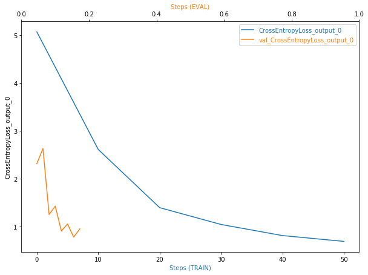

```python
plot_tensor(trial, "CrossEntropyLoss_output_0")
```

Profiler Report

```python
rule_output_path = estimator.output_path + estimator.latest_training_job.job_name + "/rule-output"
rule_output_path
```

```
's3://sagemaker-us-east-1-924884738416/pytorch-training-2022-01-14-19-25-06-626/rule-output'
```

```python
! aws s3 ls {rule_output_path} --recursive
```

```
2022-01-14 19:54:01     364848 pytorch-training-2022-01-14-19-25-06-626/rule-output/ProfilerReport/profiler-output/profiler-report.html
2022-01-14 19:54:00     211916 pytorch-training-2022-01-14-19-25-06-626/rule-output/ProfilerReport/profiler-output/profiler-report.ipynb
2022-01-14 19:53:56        192 pytorch-training-2022-01-14-19-25-06-626/rule-output/ProfilerReport/profiler-output/profiler-reports/BatchSize.json
2022-01-14 19:53:56        200 pytorch-training-2022-01-14-19-25-06-626/rule-output/ProfilerReport/profiler-output/profiler-reports/CPUBottleneck.json
2022-01-14 19:53:56       1901 pytorch-training-2022-01-14-19-25-06-626/rule-output/ProfilerReport/profiler-output/profiler-reports/Dataloader.json
2022-01-14 19:53:56        127 pytorch-training-2022-01-14-19-25-06-626/rule-output/ProfilerReport/profiler-output/profiler-reports/GPUMemoryIncrease.json
2022-01-14 19:53:56        199 pytorch-training-2022-01-14-19-25-06-626/rule-output/ProfilerReport/profiler-output/profiler-reports/IOBottleneck.json
2022-01-14 19:53:56        119 pytorch-training-2022-01-14-19-25-06-626/rule-output/ProfilerReport/profiler-output/profiler-reports/LoadBalancing.json
2022-01-14 19:53:56        151 pytorch-training-2022-01-14-19-25-06-626/rule-output/ProfilerReport/profiler-output/profiler-reports/LowGPUUtilization.json
2022-01-14 19:53:56        231 pytorch-training-2022-01-14-19-25-06-626/rule-output/ProfilerReport/profiler-output/profiler-reports/MaxInitializationTime.json
2022-01-14 19:53:56       1280 pytorch-training-2022-01-14-19-25-06-626/rule-output/ProfilerReport/profiler-output/profiler-reports/OverallFrameworkMetrics.json
2022-01-14 19:53:56        467 pytorch-training-2022-01-14-19-25-06-626/rule-output/ProfilerReport/profiler-output/profiler-reports/OverallSystemUsage.json
2022-01-14 19:53:56        157 pytorch-training-2022-01-14-19-25-06-626/rule-output/ProfilerReport/profiler-output/profiler-reports/StepOutlier.json
```

```python
! aws s3 cp {rule_output_path} ./ --recursive
```

[output not shown]

```python
import os

# get the autogenerated folder name of profiler report
profiler_report_name = [
    rule["RuleConfigurationName"]
    for rule in estimator.latest_training_job.rule_job_summary()
    if "Profiler" in rule["RuleConfigurationName"]
][0]
```

```python
import IPython

IPython.display.HTML(filename=profiler_report_name + "/profiler-output/profiler-report.html")
```

SageMaker Debugger Profiling Report

SageMaker Debugger auto generated this report. You can generate similar reports on all supported training jobs. The report provides summary of training job, system resource usage statistics, framework metrics, rules summary, and detailed analysis from each rule. The graphs and tables are interactive.

**Legal disclaimer:** This report and any recommendations are provided for informational purposes only and are not definitive. You are responsible for making your own independent assessment of the information.

```
# Parameters
processing_job_arn = "arn:aws:sagemaker:us-east-1:924884738416:processing-job/pytorch-training-2022-01-1-profilerreport-ca50b030"
```

Training job summary

[interactive chart not shown]

System usage statistics

[interactive chart not shown]

Framework metrics summary

[interactive chart not shown]

Overview: CPU operators

[interactive chart not shown]

Rules summary

The following table shows a profiling summary of the Debugger built-in rules. The table is sorted by the rules that triggered the most frequently. During your training job, the Dataloader rule was the most frequently triggered. It processed 11 datapoints and was triggered 1 times.

|  | Description | Recommendation | Number of times rule triggered | Number of datapoints | Rule parameters |
| --- | --- | --- | --- | --- | --- |
| Dataloader | Checks how many data loaders are running in parallel and whether the total number is equal the number of available CPU cores. The rule triggers if number is much smaller or larger than the number of a… | Change the number of data loader processes. | 1 | 11 | min_threshold:70 max_threshold:200 |
| CPUBottleneck | Checks if the CPU utilization is high and the GPU utilization is low. It might indicate CPU bottlenecks, where the GPUs are waiting for data to arrive from the CPUs. The rule evaluates the CPU and GPU… | Consider increasing the number of data loaders or applying data pre-fetching. | 0 | 2643 | threshold:50 cpu_threshold:90 gpu_threshold:10 patience:1000 |
| LoadBalancing | Detects workload balancing issues across GPUs. Workload imbalance can occur in training jobs with data parallelism. The gradients are accumulated on a primary GPU, and this GPU might be overused with … | Choose a different distributed training strategy or a different distributed training framework. | 0 | 0 | threshold:0.2 patience:1000 |
| LowGPUUtilization | Checks if the GPU utilization is low or fluctuating. This can happen due to bottlenecks, blocking calls for synchronizations, or a small batch size. | Check if there are bottlenecks, minimize blocking calls, change distributed training strategy, or increase the batch size. | 0 | 0 | threshold_p95:70 threshold_p5:10 window:500 patience:1000 |
| GPUMemoryIncrease | Measures the average GPU memory footprint and triggers if there is a large increase. | Choose a larger instance type with more memory if footprint is close to maximum available memory. | 0 | 0 | increase:5 patience:1000 window:10 |
| MaxInitializationTime | Checks if the time spent on initialization exceeds a threshold percent of the total training time. The rule waits until the first step of training loop starts. The initialization can take longer if do… | Initialization takes too long. If using File mode, consider switching to Pipe mode in case you are using TensorFlow framework. | 0 | 75 | threshold:20 |
| StepOutlier | Detects outliers in step duration. The step duration for forward and backward pass should be roughly the same throughout the training. If there are significant outliers, it may indicate a system stall… | Check if there are any bottlenecks (CPU, I/O) correlated to the step outliers. | 0 | 75 | threshold:3 mode:None n_outliers:10 stddev:3 |
| BatchSize | Checks if GPUs are underutilized because the batch size is too small. To detect this problem, the rule analyzes the average GPU memory footprint, the CPU and the GPU utilization. | The batch size is too small, and GPUs are underutilized. Consider running on a smaller instance type or increasing the batch size. | 0 | 2641 | cpu_threshold_p95:70 gpu_threshold_p95:70 gpu_memory_threshold_p95:70 patience:1000 window:500 |
| IOBottleneck | Checks if the data I/O wait time is high and the GPU utilization is low. It might indicate IO bottlenecks where GPU is waiting for data to arrive from storage. The rule evaluates the I/O and GPU utili… | Pre-fetch data or choose different file formats, such as binary formats that improve I/O performance. | 0 | 2643 | threshold:50 io_threshold:50 gpu_threshold:10 patience:1000 |

Analyzing the training loop

Step duration analysis

[interactive chart not shown]

GPU utilization analysis

**Usage per GPU**

[interactive chart not shown]

**Workload balancing**

[interactive chart not shown]

Dataloading analysis

[interactive chart not shown]

Batch size

[interactive chart not shown]

CPU bottlenecks

[interactive chart not shown]

I/O bottlenecks

[interactive chart not shown]

GPU memory

[interactive chart not shown]

[figure not shown]

## Model Deploying

```python
from sagemaker.pytorch import PyTorchModel
#An PyTorch SageMaker Model that can be deployed to a SageMaker Endpoint
pytorch_model = PyTorchModel(model_data=estimator.model_data,
                             role=role,
                             entry_point='inference.py',
                             py_version='py36',
                             framework_version='1.8')


predictor = pytorch_model.deploy(initial_instance_count=1, instance_type='ml.m5.xlarge')
```

```
-----!
```

```python
# TODO: Run an prediction on the endpoint
from sagemaker.serializers import IdentitySerializer
predictor.serializer = IdentitySerializer("image/jpeg")
from PIL import Image
from IPython.display import Image as ImageDisplay
import io
#To identify dog breed from images we provide
def identify_dog(image_path):
    buf = io.BytesIO()
    Image.open(image_path).save(buf, format="JPEG")
    response = predictor.predict(buf.getvalue())

    folders = list(os.listdir("./dogImages/train"))
    folders.sort()
    return folders[list(response[0]).index(max(response[0]))]
```

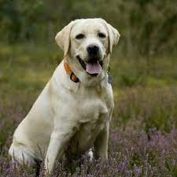

```python
test_image = "./test_dogs/labrador.jpg"
ImageDisplay(test_image)
```

```python
identify_dog(test_image)
```

```
'096.Labrador_retriever'
```

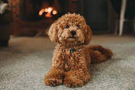

```python
test_image = "./test_dogs/poodle.jpg"
ImageDisplay(test_image)
```

```python
identify_dog(test_image)
```

```
'088.Irish_water_spaniel'
```

```python
# TODO: Remember to shutdown/delete your endpoint once your work is done
predictor.delete_endpoint()
```